# A Warning in Time Series

Cook, Luke A

**Data Summary**  
The following analysis is of COVID-19 confirmed cases in the country of “Timeseria” and includes two Time Series models.These models are compared and the better of these two models is then used to predict future values of where confirmed cases could be headed in the next ten days.  
**1 Exploratory Data Analysis**

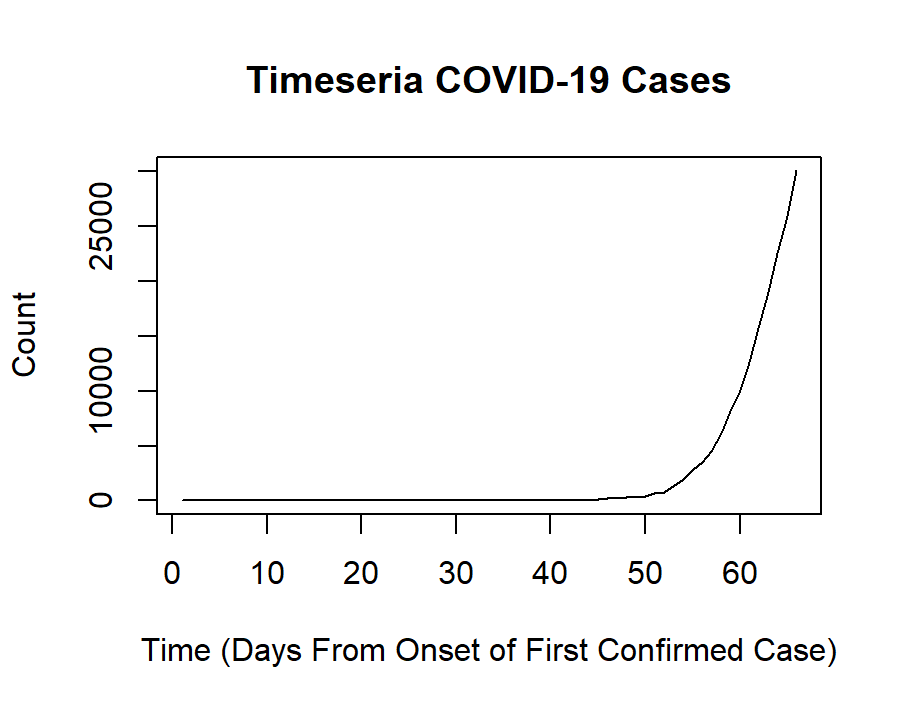

Figure 1: The dataset I will be analyzing. Notice the “exponential” trend we’ve been hearing so much about from health officials in the news. Seasonality to any meaningful degree is absent from this dataset and homoskedasticity isn’t present.  
**2 Models Considered**  
I built two models to fit the data. Both models utilize a logarithmic VST and twice differencing. The first uses an AR(1) model while the second uses an ARMA(1,1) model with a quadratic trend. I avoided seasonal components as they don’t appear to exist.  
**Model A**  
Model A is an ARMA(1,0) model which uses a VST of log thats been twice differenced to remove trend and heteroskedasticity. I chose to pursue ARMA parameters as I still did not have white noise after pursuing stationarity. The ACF indicated there wasn’t an obvious MA process so I experimented with an AR(1) for my first model following an auto.arima suggestion and the look of the pACF of my data. I also initially avoided a quadratic trend because of fears it’d ruin later forecasts.

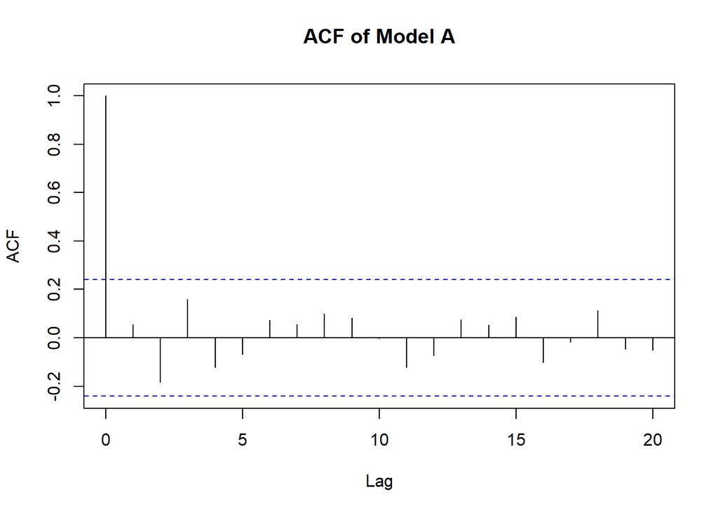

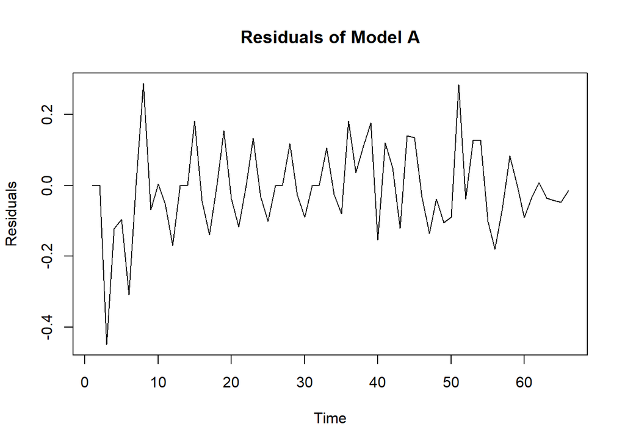

Figure 2: Residuals of Model A with the ACF of Model A. Note the residuals appearing close to white noise and the ACF without significant signs of further AR processes  
**Model B**  
Model B is an ARMA(1,1) process which also uses a log VST and twice differencing but includes a quadratic curve in its trend elimination. Initially I’d desired to only use once differencing with the quadratic trend but this was not stationary enough for consideration.

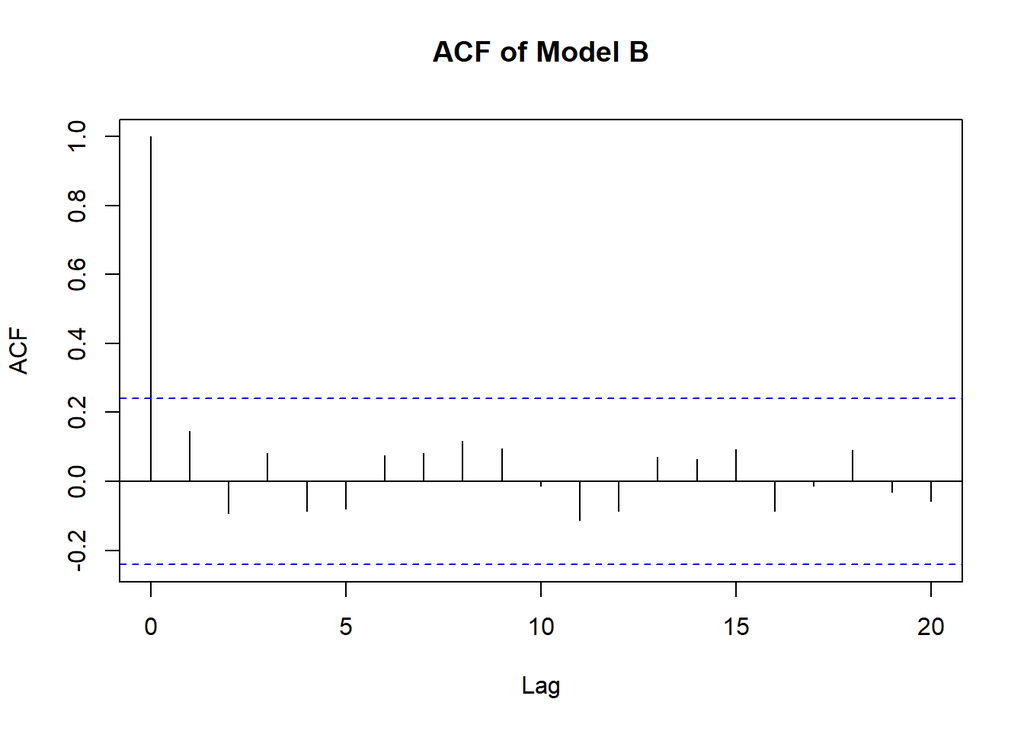

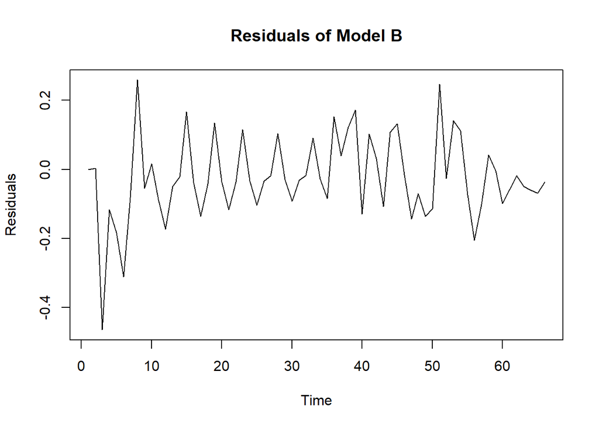

Figure 3: Residuals of Model B with the ACF of Model B.  
**Chosen Model**

| Models | AIC | BIC |
| --- | --- | --- |
| Model A | -1.246 | -1.179 |
| Model B | -1.217 | -1.116 |

While very close in their comparison criterion, Model A (without an MA element or a quadratic trend in its trend estimation) seems to be the slightly better of the two models and will be the once used in forecasting.  
**Results**  
My chosen model only has one parameter from its AR component and that parameter is estimated to be -0.7617 by the arima function.

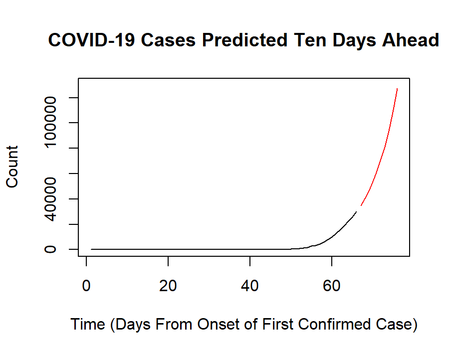

Figure 4: Here are the next ten days of cases as predicted by my model. Of course, this model does not consider the impacts of quarantines, social-distancing, or lockdowns could have on the number of confirmed cases. This models stands instead as a warning.

**Appendix:Code**

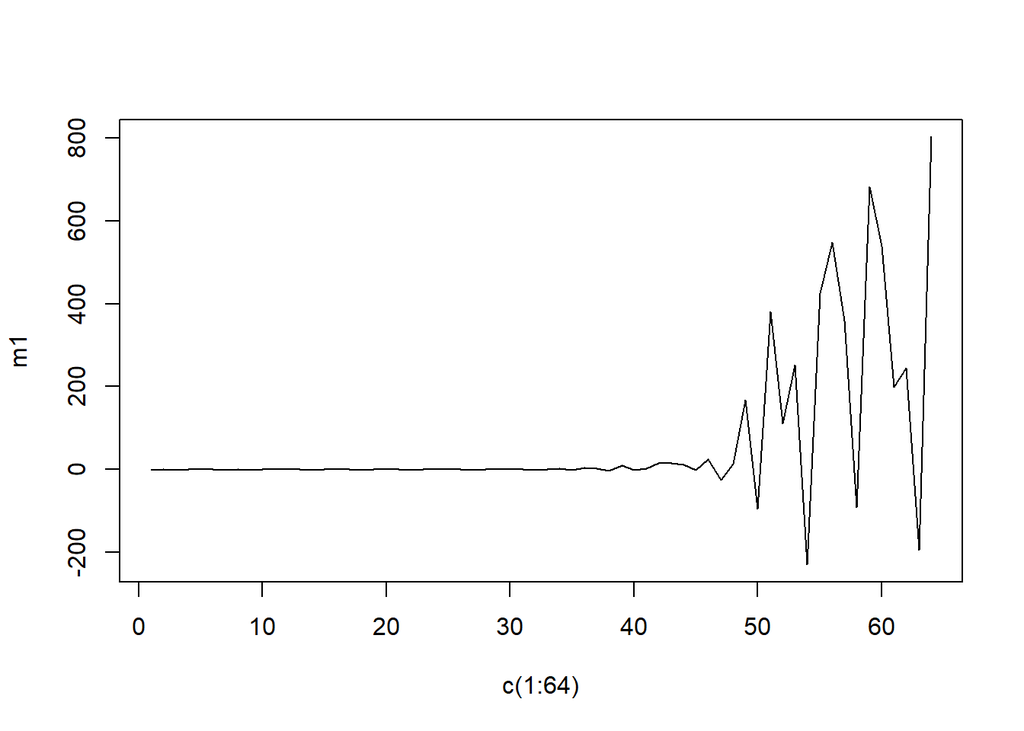

```r
#eliminate trend
m1=diff(diff(COVID$Count))
plot(c(1:64),m1,type="l")
```

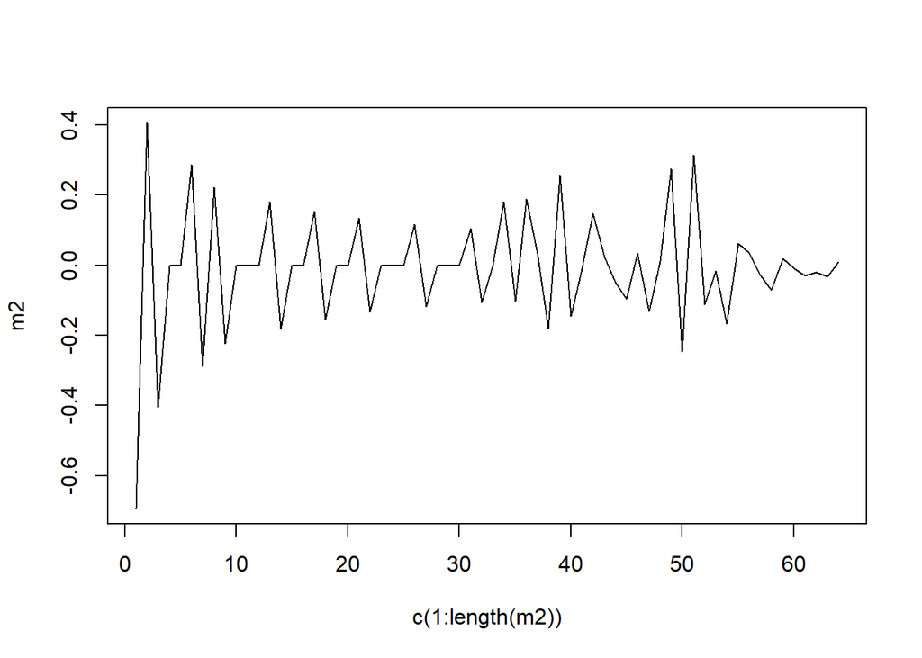

```r
#fix heteroskedasticity
m2=diff(diff(log(COVID$Count)))
plot(c(1:length(m2)),m2,type="l")
```

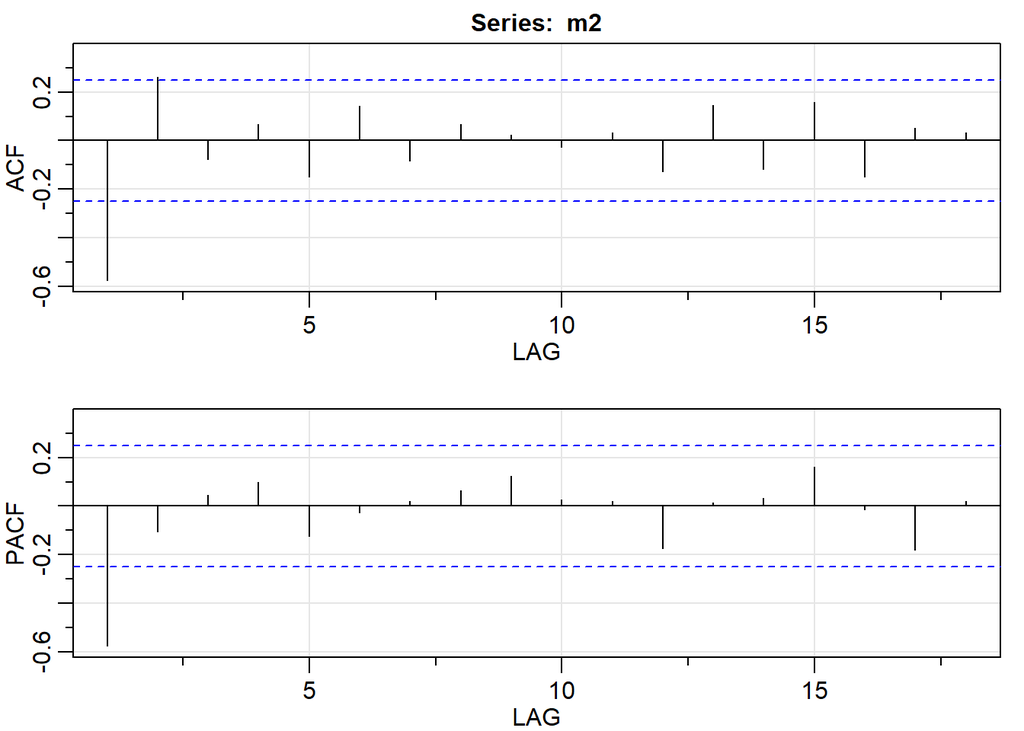

```
##       [,1]  [,2]  [,3] [,4]  [,5]  [,6]  [,7] [,8] [,9] [,10] [,11] [,12] [,13]
## ACF  -0.58  0.26 -0.08 0.07 -0.15  0.14 -0.08 0.07 0.02 -0.03  0.03 -0.13  0.15
## PACF -0.58 -0.11  0.04 0.10 -0.12 -0.03  0.02 0.07 0.13  0.03  0.02 -0.17  0.01
##      [,14] [,15] [,16] [,17] [,18]
## ACF  -0.12  0.16 -0.15  0.05  0.03
## PACF  0.03  0.16 -0.02 -0.18  0.02
```

```r
acf2(m2)
```

```r
#auto arima will provide a good base point for guessing AR(p) but take care to note the lack of sample size might be a serious problem
auto.arima(diff(diff(log(COVID$Count))))
```

```
## Series: diff(diff(log(COVID$Count)))
## ARIMA(1,0,0) with zero mean
##
## Coefficients:
##           ar1
##       -0.7617
## s.e.   0.1029
##
## sigma^2 estimated as 0.01585:  log likelihood=41.88
## AIC=-79.76   AICc=-79.56   BIC=-75.44
```

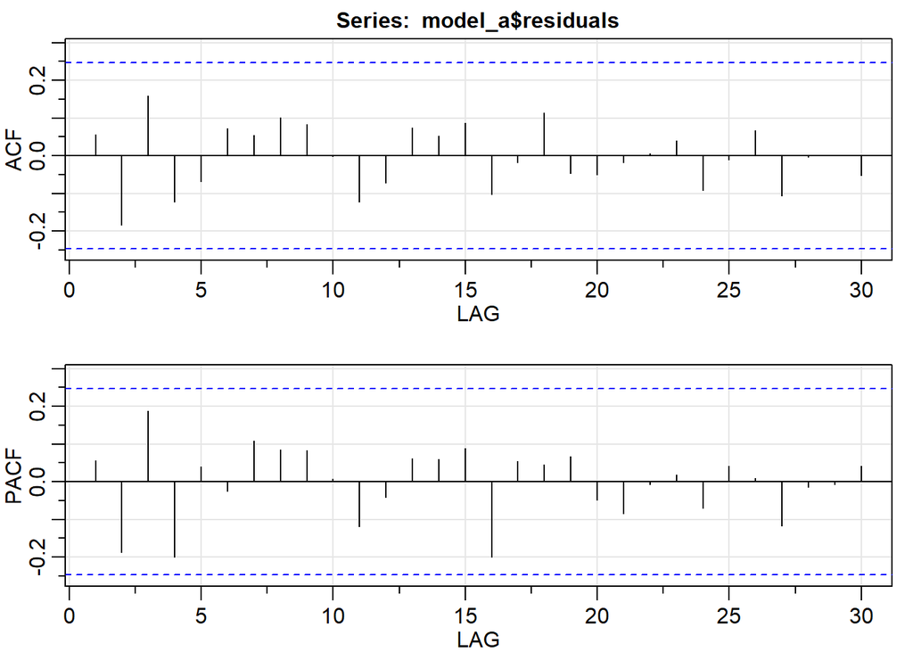

```
##      [,1]  [,2] [,3]  [,4]  [,5]  [,6] [,7] [,8] [,9] [,10] [,11] [,12] [,13]
## ACF  0.06 -0.18 0.16 -0.12 -0.07  0.07 0.05 0.10 0.08  0.00 -0.12 -0.07  0.07
## PACF 0.06 -0.19 0.19 -0.20  0.04 -0.03 0.11 0.08 0.08  0.01 -0.12 -0.04  0.06
##      [,14] [,15] [,16] [,17] [,18] [,19] [,20] [,21] [,22] [,23] [,24] [,25]
## ACF   0.05  0.09  -0.1 -0.02  0.11 -0.05 -0.05 -0.02  0.01  0.04 -0.09 -0.01
## PACF  0.06  0.09  -0.2  0.05  0.05  0.07 -0.05 -0.09 -0.01  0.02 -0.07  0.04
##      [,26] [,27] [,28] [,29] [,30]
## ACF   0.07 -0.11  0.00  0.00 -0.05
## PACF  0.01 -0.12 -0.01 -0.01  0.04
```

```r
l1 = log(COVID$Count)
#Start with suggested value of p,q
model_a = arima(l1,order=c(1,2,0))
acf2(model_a$residuals,max.lag=30)
```

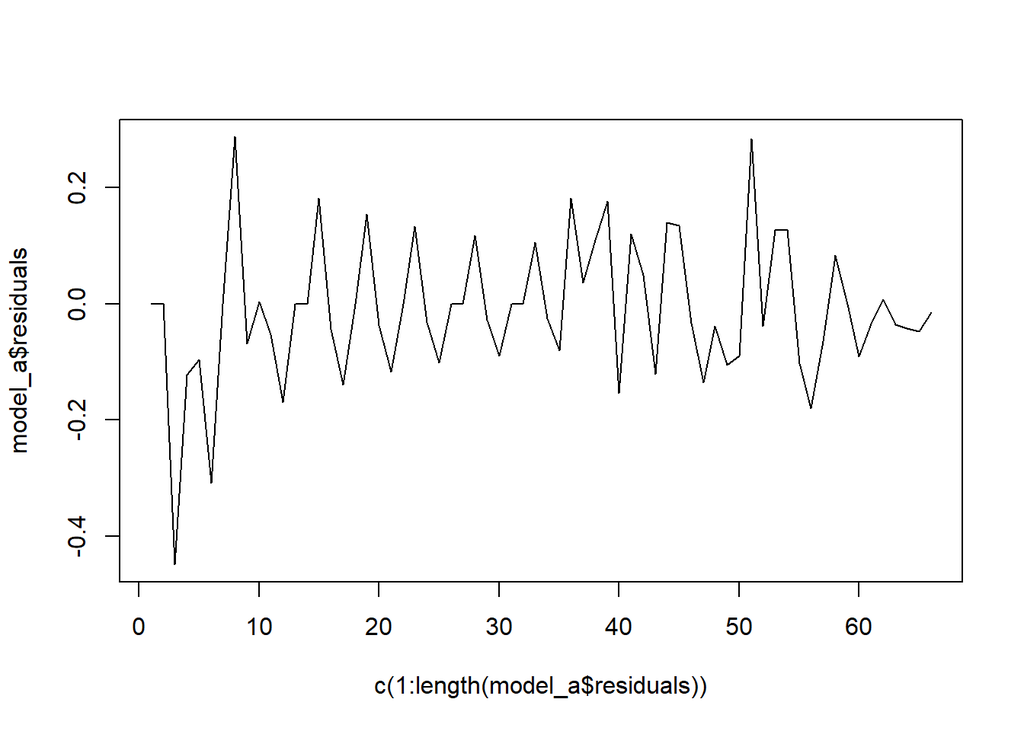

```r
plot(c(1:length(model_a$residuals)),model_a$residuals,type="l")
```

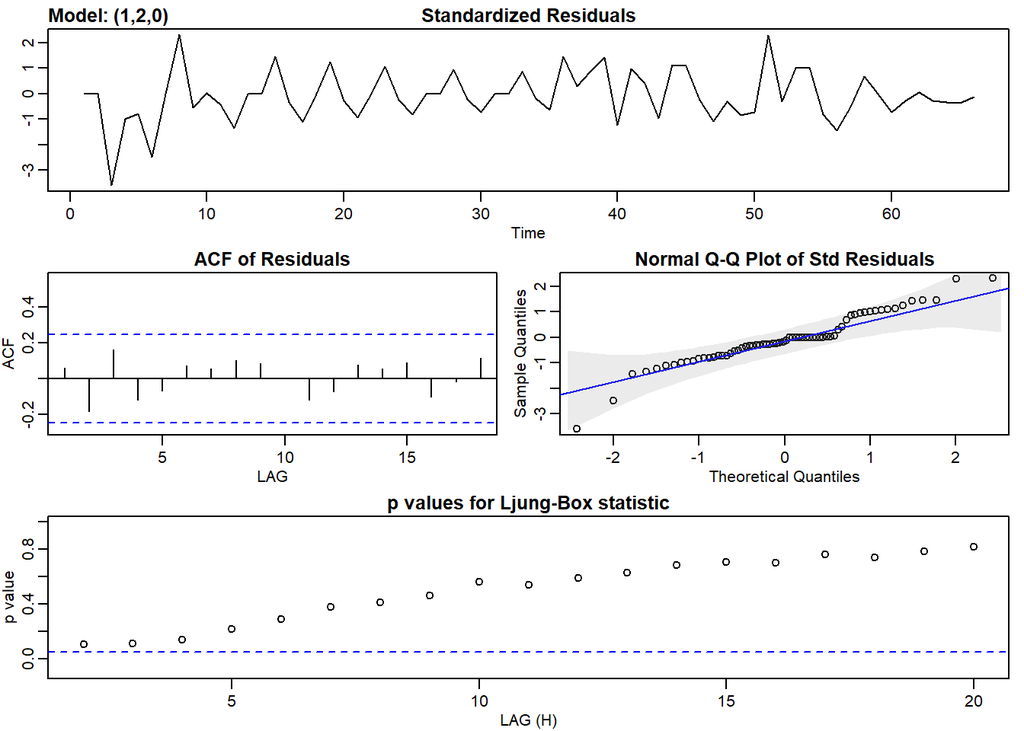

```
## $fit
##
## Call:
## stats::arima(x = xdata, order = c(p, d, q), seasonal = list(order = c(P, D,
##     Q), period = S), include.mean = !no.constant, transform.pars = trans, fixed = fixed,
##     optim.control = list(trace = trc, REPORT = 1, reltol = tol))
##
## Coefficients:
##           ar1
##       -0.7617
## s.e.   0.1029
##
## sigma^2 estimated as 0.01561:  log likelihood = 41.88,  aic = -79.76
##
## $degrees_of_freedom
## [1] 63
##
## $ttable
##     Estimate     SE t.value p.value
## ar1  -0.7617 0.1029 -7.4001       0
##
## $AIC
## [1] -1.246211
##
## $AICc
## [1] -1.245203
##
## $BIC
## [1] -1.178746
```

```r
sarima(l1,p=1,d=2,q=0)
```

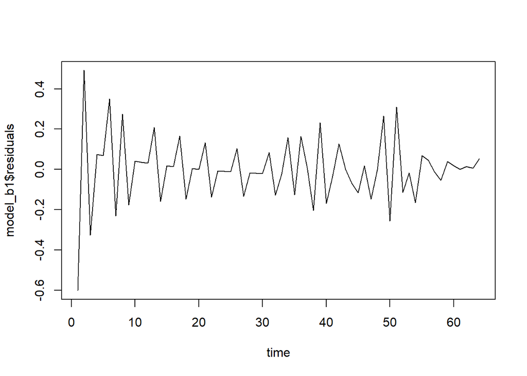

```r
#consider a quadratic eliminate in model B
time= c(1:64)
model_b1 = lm(diff(diff(log(COVID$Count))) ~ time + I(time^2))
plot(time,model_b1$residuals,type="l")
```

```r
#use auto.arima as a baseline for what to expect for ARMA p and q
auto.arima(model_b1$residuals)
```

```
## Series: model_b1$residuals
## ARIMA(1,0,1) with zero mean
##
## Coefficients:
##           ar1      ma1
##       -0.5828  -0.2865
## s.e.   0.1651   0.1811
##
## sigma^2 estimated as 0.01483:  log likelihood=44.56
## AIC=-83.12   AICc=-82.72   BIC=-76.65
```

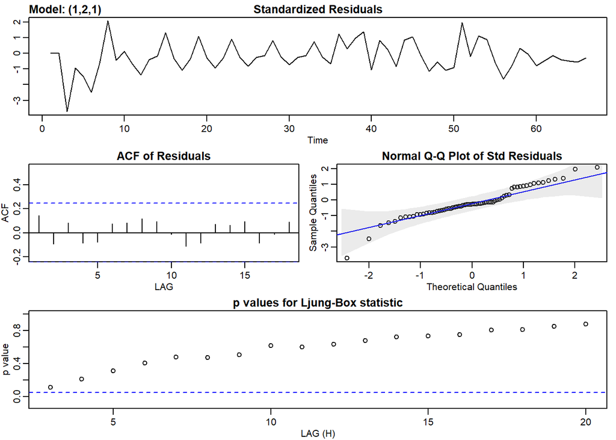

```
## $fit
##
## Call:
## stats::arima(x = xdata, order = c(p, d, q), seasonal = list(order = c(P, D,
##     Q), period = S), include.mean = !no.constant, transform.pars = trans, fixed = fixed,
##     optim.control = list(trace = trc, REPORT = 1, reltol = tol))
##
## Coefficients:
##           ar1      ma1
##       -0.6390  -0.2284
## s.e.   0.1677   0.2038
##
## sigma^2 estimated as 0.01557:  log likelihood = 41.95,  aic = -77.9
##
## $degrees_of_freedom
## [1] 62
##
## $ttable
##     Estimate     SE t.value p.value
## ar1  -0.6390 0.1677 -3.8098  0.0003
## ma1  -0.2284 0.2038 -1.1208  0.2667
##
## $AIC
## [1] -1.217173
##
## $AICc
## [1] -1.214099
##
## $BIC
## [1] -1.115975
```

```r
time = c(1:66)
l2 = lm(log(COVID$Count)~time+I(time^2))
model_b = arima(l2$residuals,order=c(1,2,1))
sarima(l2$residuals,p=1,d=2,q=1)
```

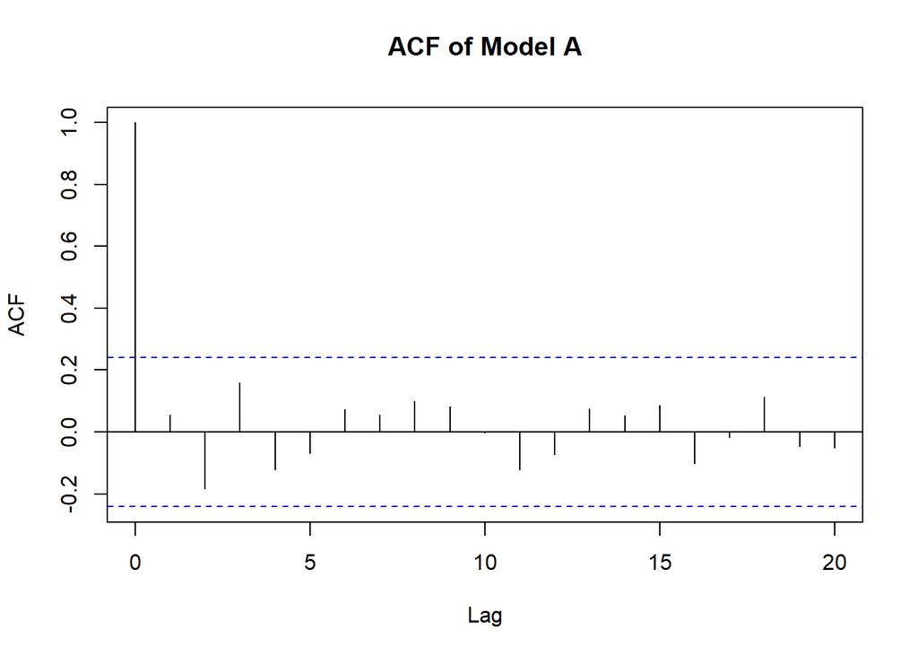

```r
model_a = arima(log(COVID$Count),order=c(1,2,0))
acf(model_a$residuals,main="ACF of Model A",lag.max=20)
```

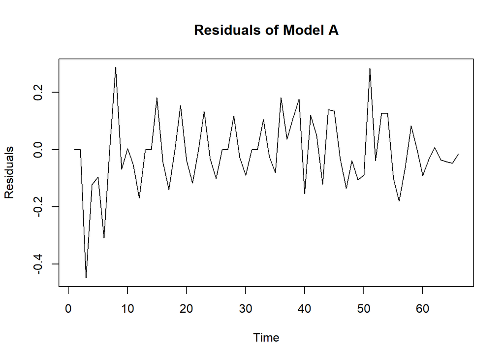

```r
plot(c(1:66),model_a$residuals,type="l",main="Residuals of Model A",xlab="Time",ylab="Residuals")
```

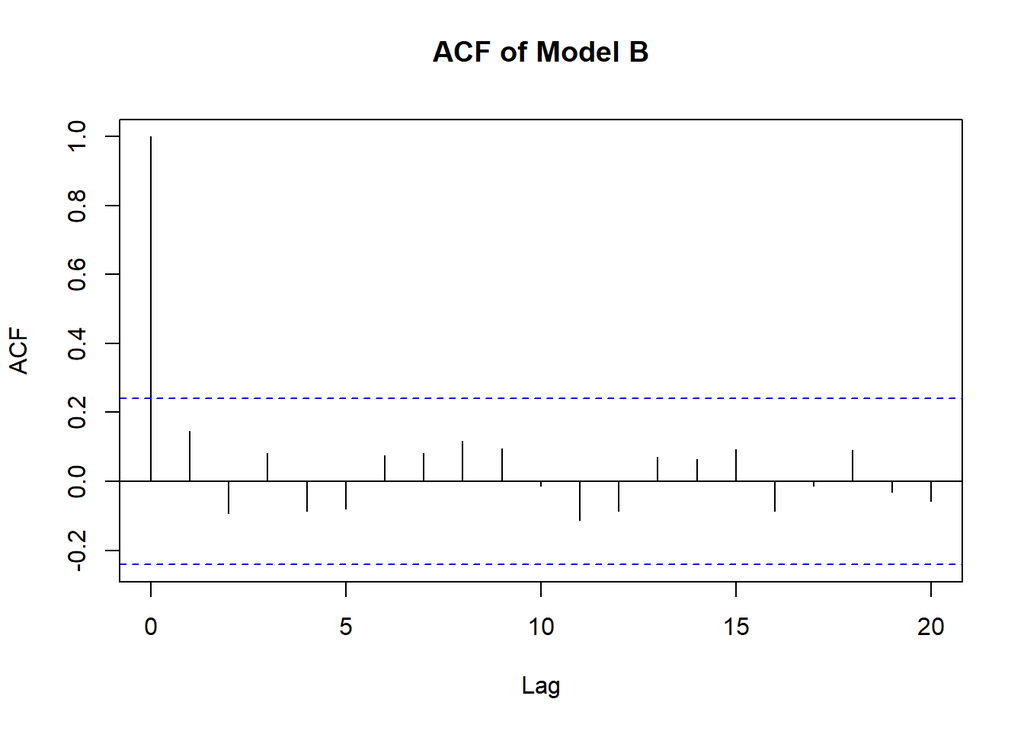

```r
time = c(1:66)
l2 = lm(log(COVID$Count)~time+I(time^2))
model_b = arima(l2$residuals,order=c(1,2,1))
acf(model_b$residuals,main="ACF of Model B",lag.max=20)
```

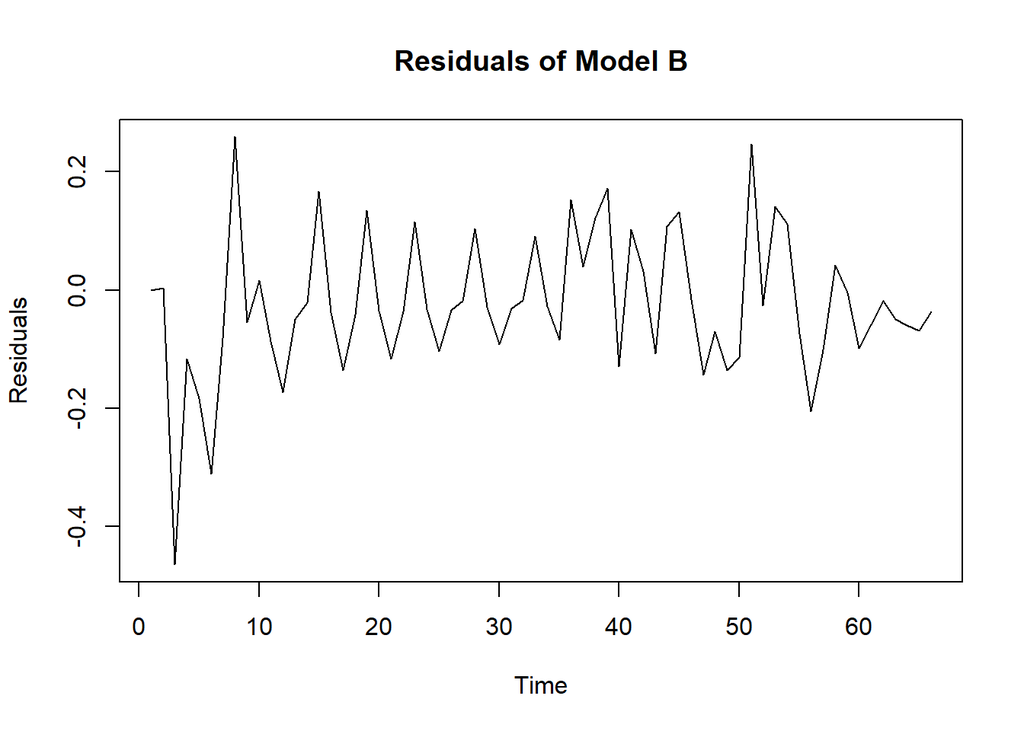

```r
plot(c(1:length(model_b$residuals)),model_b$residuals,main="Residuals of Model B",type="l",xlab="Time",ylab="Residuals")
```

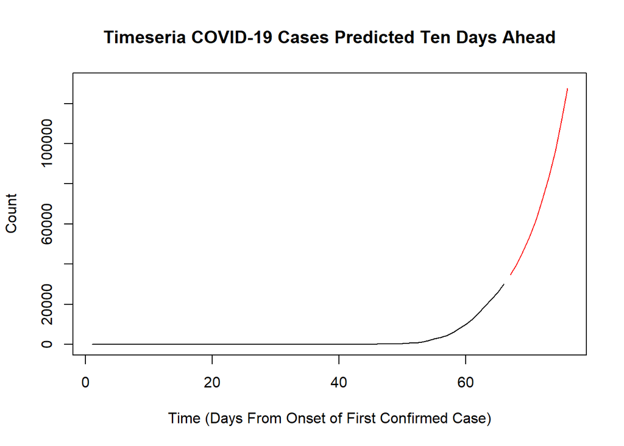

```r
l1 = log(COVID$Count)
model = arima(l1,order=c(1,2,0),include.mean = FALSE)
forecast = predict(model,n.ahead=10)
for (x in 1:10){
  forecast$pred[x] = exp(forecast$pred[x])
}
predictions = forecast$pred
COVID_w_pred = c(COVID$Count,predictions)
plot(1:66,COVID$Count,xlab="Time (Days From Onset of First Confirmed Case)", ylab="Count",main="Timeseria COVID-19 Cases Predicted Ten Days Ahead",type="l",xlim = c(1,76),ylim=c(0,130000))
lines(c(67:76),predictions,col="red",type="l")
```